# Simulação e intervalos de credibilidade aplicados à análise de pesquisas eleitorais

Programa de Pós-Graduação em Modelagem de Sistemas Complexos da Escola de Artes, Ciências e Humanidades da Universidade de São Paulo (USP/EACH) - Simulação de Sistemas Complexos II (SCX5005) - Profº Marcelo Lauretto

Pedro Almeida (nº USP: 10665237)

5 de janeiro de 2019

### Exercício de programação 2: Simulação e intervalos de credibilidade aplicados à análise de pesquisas eleitorais

Usaremos os dados do arquivo pesquisa_1T.txt contendo as pesquisas eleitorais do 1º turno, realizadas de 1 a 29/09/2018. Consideraremos os candidatos: B, H, C, O, BN.

```r
pesquisa_1T <- read.table("pesquisa_1T.txt", header = TRUE) # carregando o arquivo pesquisa_1T.txt e criando um objeto
```

**Tarefas:**

1. Ajustar as séries de pesquisas eleitorais por uma regressão Dirichlet. Considere como covariáveis o dia da pesquisa (número sequencial em que 01/09 corresponde ao dia 1) e a raiz quadrada do dia. Use a função DirichReg do pacote DirichletReg.

```r
library(DirichletReg) # carregando o pacote DirichletReg

pesquisa_1T$Y <- DR_data(pesquisa_1T[,2:6]) # preparando a variável Y

mod <- DirichReg(Y ~ dia + sqrt(dia), pesquisa_1T) # modelo
```

```r
output <- predict.DirichletRegModel(object = mod, newdata = data.frame(dia = c(1:37)), mu = TRUE, alpha = TRUE) # predizendo os votos do dia 1 ao dia 37
output
```

```
## $mu
##            [,1]       [,2]       [,3]      [,4]      [,5]
##  [1,] 0.2342489 0.06057228 0.11788976 0.3061435 0.2811456
##  [2,] 0.2368947 0.06858102 0.11807093 0.2997598 0.2766935
##  [3,] 0.2397098 0.07563519 0.11812896 0.2947268 0.2717992
##  [4,] 0.2425895 0.08227388 0.11810261 0.2903493 0.2666848
##  [5,] 0.2454922 0.08869960 0.11800723 0.2863601 0.2614409
##  [6,] 0.2483959 0.09501276 0.11785089 0.2826236 0.2561168
##  [7,] 0.2512868 0.10127071 0.11763855 0.2790601 0.2507438
##  [8,] 0.2541549 0.10750914 0.11737363 0.2756186 0.2453437
##  [9,] 0.2569928 0.11375141 0.11705865 0.2722643 0.2399328
## [10,] 0.2597943 0.12001335 0.11669564 0.2689727 0.2345241
## [11,] 0.2625543 0.12630586 0.11628629 0.2657257 0.2291278
## [12,] 0.2652684 0.13263646 0.11583210 0.2625101 0.2237530
## [13,] 0.2679326 0.13901023 0.11533442 0.2593157 0.2184070
```

[output cut: 64 more lines]

3. Calcular os intervalos de credibilidade dos votos em cada candidato por data (do dia 1 até o dia 37), via máxima densidade a posteriori (HPD). Plotar o gráfico para cada candidato.

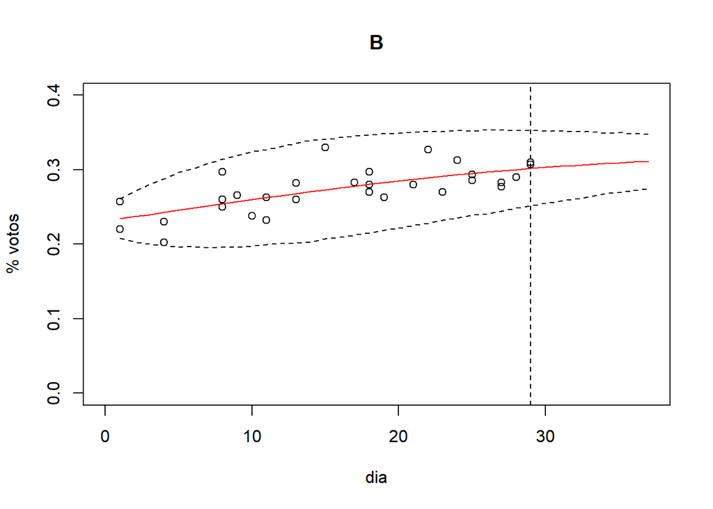

```r
# Input:
#   a,b: hiperparâmetros da distribuição beta
#   cred: nível de credibilidade
#   M: tamanho da amostra para simulação

# Output:
#   xlim: intervalos inferiores e superiores

ic_hpd_beta = function(a, b, cred = 0.95, M = 1e+4){
  x = rbeta(M, a, b) # sorteio dos pontos
  fx = dbeta(x, a, b) # cálculo das densidades
  fxs = quantile(fx, 1 - cred)
  idx = which(fx >= fxs)
  xsel = x[idx]
  fxsel = fx[idx]
  xlim = data.frame(min = c(min(xsel)), max = c(max(xsel)))
  return(xlim)
}

# gráfico para o candidato B
B_hpd <- c()

for(i in 1:37){
  B_hpd[[i]] = ic_hpd_beta(a = output[[2]][i,1], b = sum(output[[2]][i,2:5]), cred = 0.95, M = 1e+4)
}

df_B <- do.call(rbind.data.frame, B_hpd)

plot(pesquisa_1T$dia, pesquisa_1T$B, xlab = 'dia', ylab = '% votos', main = 'B', xlim = c(0, 37), ylim = c(0, 0.4))
lines(seq(1:37), output[[1]][,1], type = 'l', col = "red")
lines(seq(1:37), df_B$max, type = 'l', lty = 'dashed', col = 'black')
lines(seq(1:37), df_B$min, type = 'l', lty = 'dashed', col = 'black')
abline(v = 29, lty = 'dashed')
```

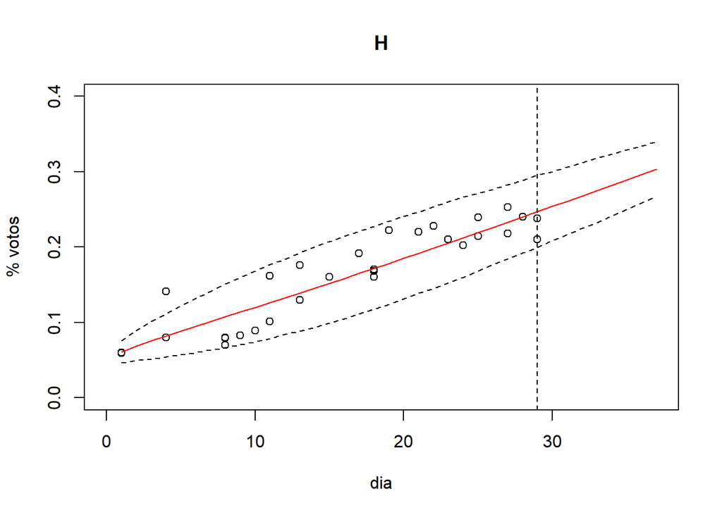

```r
# gráfico para o candidato H
H_hpd <- c()

for(i in 1:37){
  H_hpd[[i]] = ic_hpd_beta(a = output[[2]][i,2], b = sum(output[[2]][i,-2]), cred = 0.95, M = 1e+4)
}

df_H <- do.call(rbind.data.frame, H_hpd)

plot(pesquisa_1T$dia, pesquisa_1T$H, xlab = 'dia', ylab = '% votos', main = 'H', xlim = c(0, 37), ylim = c(0, 0.4))
lines(seq(1:37), output[[1]][,2], type = 'l', col = "red")
lines(seq(1:37), df_H$max, type = 'l', lty = 'dashed', col = 'black')
lines(seq(1:37), df_H$min, type = 'l', lty = 'dashed', col = 'black')
abline(v = 29, lty = 'dashed')
```

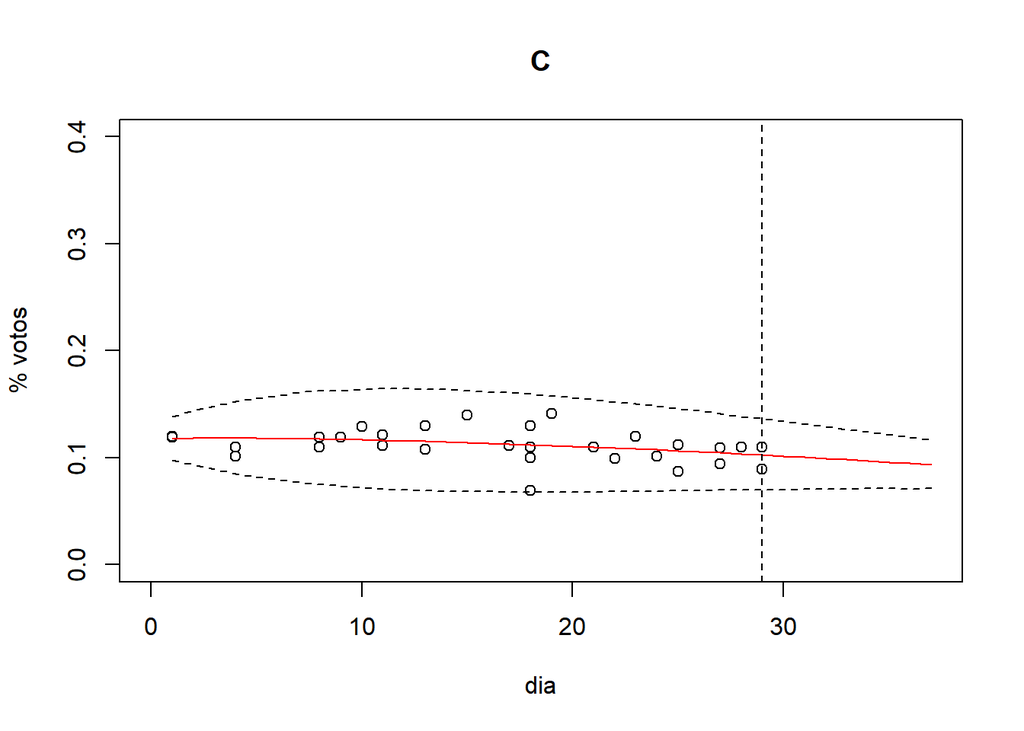

```r
# gráfico para o candidato C
C_hpd <- c()

for(i in 1:37){
  C_hpd[[i]] = ic_hpd_beta(a = output[[2]][i,3], b = sum(output[[2]][i,-3]), cred = 0.95, M = 1e+4)
}

df_C <- do.call(rbind.data.frame, C_hpd)

plot(pesquisa_1T$dia, pesquisa_1T$C, xlab = 'dia', ylab = '% votos', main = 'C', xlim = c(0, 37), ylim = c(0, 0.4))
lines(seq(1:37), output[[1]][,3], type = 'l', col = "red")
lines(seq(1:37), df_C$max, type = 'l', lty = 'dashed', col = 'black')
lines(seq(1:37), df_C$min, type = 'l', lty = 'dashed', col = 'black')
abline(v = 29, lty = 'dashed')
```

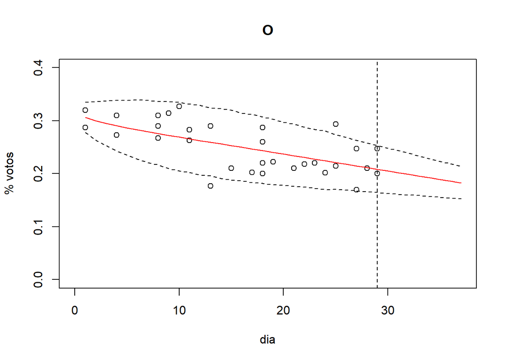

```r
# gráfico para o candidato O
O_hpd <- c()

for(i in 1:37){
  O_hpd[[i]] = ic_hpd_beta(a = output[[2]][i,4], b = sum(output[[2]][i,-4]), cred = 0.95, M = 1e+4)
}

df_O <- do.call(rbind.data.frame, O_hpd)

plot(pesquisa_1T$dia, pesquisa_1T$O, xlab = 'dia', ylab = '% votos', main = 'O', xlim = c(0, 37), ylim = c(0, 0.4))
lines(seq(1:37), output[[1]][,4], type = 'l', col = "red")
lines(seq(1:37), df_O$max, type = 'l', lty = 'dashed', col = 'black')
lines(seq(1:37), df_O$min, type = 'l', lty = 'dashed', col = 'black')
abline(v = 29, lty = 'dashed')
```

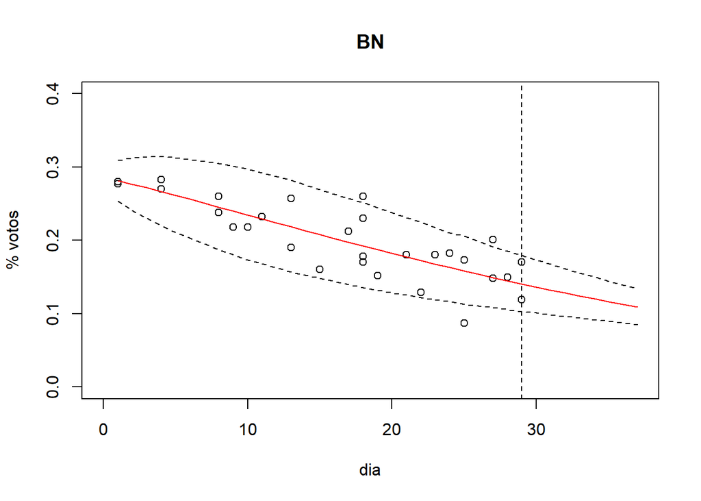

```r
# gráfico para o candidato BN
BN_hpd <- c()

for(i in 1:37){
  BN_hpd[[i]] = ic_hpd_beta(a = output[[2]][i,5], b = sum(output[[2]][i,-5]), cred = 0.95, M = 1e+4)
}

df_BN <- do.call(rbind.data.frame, BN_hpd)

plot(pesquisa_1T$dia, pesquisa_1T$BN, xlab = 'dia', ylab = '% votos', main = 'BN', xlim = c(0, 37), ylim = c(0, 0.4))
lines(seq(1:37), output[[1]][,5], type = 'l', col = "red")
lines(seq(1:37), df_BN$max, type = 'l', lty = 'dashed', col = 'black')
lines(seq(1:37), df_BN$min, type = 'l', lty = 'dashed', col = 'black')
abline(v = 29, lty = 'dashed')
```

4. Sobre os valores de alpha projetados para o dia 7/10, simule vetores theta com a respectiva distribuição dirichet; sobre esses vetores theta simulados:

4.1) Plote um histograma das diferenças entre a proporção de votos no candidato B e a proporção de votos no candidato H

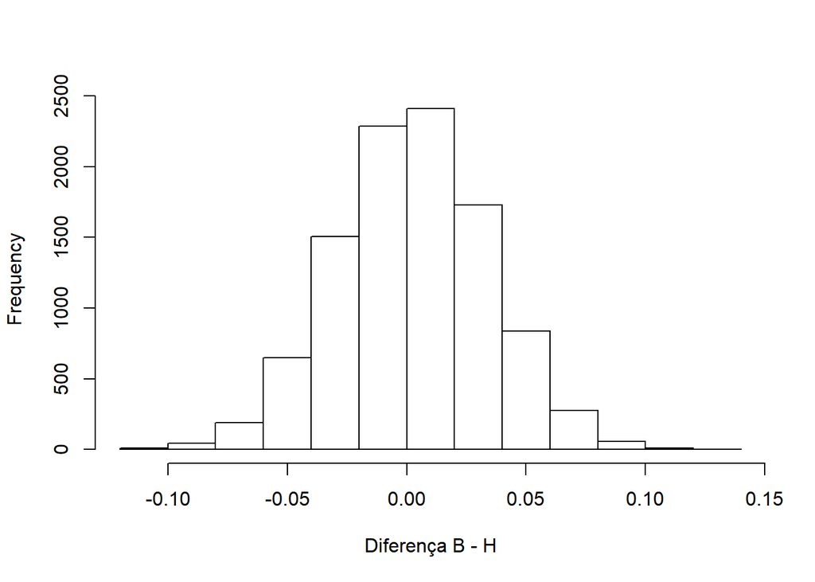

```r
dir <- rdirichlet(n = 1e+4, alpha = output[[2]][37,])
B_dir <- dir[,1]
H_dir <- dir[,2]
BH_dir <- round(B_dir - H_dir, digits = 2)

hist(x = BH_dir, main = "", xlab = "Diferença B - H")
```

4.2) Calcule a probabilidade do candidato B ter votação maior do que o candidato H

```r
# contando o número de vezes em que a diferença entre B e H é maior que zero
tb <- table(BH_dir > 0)
tb
```

```
##
## FALSE  TRUE
##  4681  5319
```

```r
# calculando a probabilidade de B ser maior que H
prob <- as.double((tb[2] - tb[1]) / (tb[1] + tb[2]))
prob
```

```
## [1] 0.0638
```